# Lecture 10: Bootstrap

## STAT 324

### Ralph Trane

### University of Wisconsin–Madison<br><br>

### Spring 2020

# Confidence Interval: The Short Story

To find confidence interval, we use the distribution of `\(\frac{\bar{X} - E(\bar{X})}{\text{SD}(\bar{X})}\)`.

If `\(\bar{X} \sim N\)`, and `\(\text{SD}(\bar{X})\)` is known, then `\(\frac{\bar{X} - E(\bar{X})}{\text{SD}(\bar{X})} \sim N\)`.

If `\(\bar{X} \sim N\)`, and `\(\text{SD}(\bar{X})\)` is unknown, then `\(\frac{\bar{X} - E(\bar{X})}{\widehat{\text{SD}}(\bar{X})} \sim t_{n-1}\)`.

So, when is `\(\bar{X} \sim N\)`?

1. If the data are normal, i.e. `\(X_1, ..., X_n \sim N\)`.
    - check using histogram and/or QQ-plot

2. If `\(n \ge 30\)`, then CLT tells us `\(\bar{X} \sim N\)` (in most real life scenarios...)

What if the data are not normal, and `\(n < 30\)`?!?!?!?!

[figure not shown]

What is the "gold standard" for finding the distribution of anything?

Sample from the population many, many times, and create a histogram.

That's all fun and games in theory, but in practice we cannot really do that.

Remember, all of statistics is build on one fundamental assumption:

the sample looks like the population.

So what if we just...

resample from the sample...?

[figure not shown]

This approach is called *bootstraping*. How it works:

1. Grab your bootstraps

2. Pull yourself up!

[figure not shown]

This approach is called *bootstraping*. How it works:

1. Given a sample, calculate `\(\bar{x}\)`.

2. Generate a new sample of size `\(n\)` from the original sample by sampling with replacement (!)
    * we call the first new sample `\(x_{11}, x_{12}, ..., x_{1n}\)`, the second new sample `\(x_{11}, x_{12}, ..., x_{1n}\)`, ..., the `\(B\)`'th new sample `\(x_{B1}, x_{B2}, ..., x_{Bn}\)`
    * these new samples are called *bootstrap samples*

3. For each bootstrap sample, calculate `\(t_j = \frac{\bar{x}_{\cdot j} - \bar{x}}{s_j/\sqrt{n}}\)`.
    * here, `\(\bar{x}_{\cdot j}\)` is the average of the `\(j\)`'th bootstrap sample, while `\(\bar{x}\)` is the average of the original sample.

4. Estimate the distribution of `\(\frac{\bar{X} - E(\bar{X})}{\widehat{\text{SD}}(\bar{X})}\)` by the distribution of `\(t_1, t_2, ..., t_B\)`
    * that is, the true distribution of `\(\frac{\bar{X} - E(\bar{X})}{\widehat{\text{SD}}(\bar{X})}\)` is approximately the histogram of the `\(t_j\)`'s.

To find a confidence interval, we need to find `\(x_1, x_2\)` such that

$$
  P\left(x_1 \le \frac{\bar{X} - E(\bar{X})}{\widehat{\text{SD}}(\bar{X})} \le x_2 \right) = 1 - \alpha.
$$

We can use the bootstrap samples to estimate the distribution of `\(\frac{\bar{X} - E(\bar{X})}{\widehat{\text{SD}}(\bar{X})}\)`, and find the cut-offs such that there's `\(\alpha/2\)` to the left of `\(x_1\)` and `\(\alpha/2\)` to the right of `\(x_2\)`.

We will call `\(x_1 = \hat{t}_{1-\alpha/2}\)`, and `\(x_2 = \hat{t}_{\alpha/2}\)` -- the `\(1-\alpha/2\)` and `\(\alpha/2\)` critical values of the distribution of the `\(\hat{t}_j\)`'s.

Note: in this case, it is most likely that `\(\hat{t}_{1-\alpha/2} \neq -\hat{t}_{\alpha/2}\)`!!! There is no guarentee that the distribution is symmetrical, so no reason to think one of the values will be the negative of the other.

Important: since we do not (a priori) know the distribution of the `\(\hat{t}_j\)`'s, we do not know if it is symmetrical. Therefore, we do not know if `\(\hat{t}_{1-\alpha/2} = -\hat{t}_{\alpha/2}\)`. So we do actually have to find **two** values.

This code takes an origina sample (`orig_sample`), creates 5000 bootstrap samples, and calculates `\(\hat{t}_1,...,\hat{t}_{5000}\)`.

All of this will be in the data set `bootstrap_samples`.

```r
orig_sample <- tibble(x = c( 2.80, 16.47, 3.36,  9.31, 5.86,
                            15.25, 27.58, 4.75, 36.20, 1.25,
                            11.45, 10.01, 0.75,  0.59, 1.40,
                            10.54, 20.69, 1.82, 10.16, 2.83))
xbar <- mean(orig_sample$x)
sample_size <- nrow(orig_sample)

bootstrap_samples <- tibble(i = 1:5000) %>%
  mutate(boot_sample = map(i, ~sample_n(orig_sample, size = sample_size, replace = TRUE)$x),
         boot_mean = map_dbl(boot_sample, mean),
         boot_sd = map_dbl(boot_sample, sd),
         t_stat = (boot_mean - xbar)/(boot_sd/sqrt(sample_size)))
```

We can then create a histogram of the `\(\hat{t}_j\)`'s:

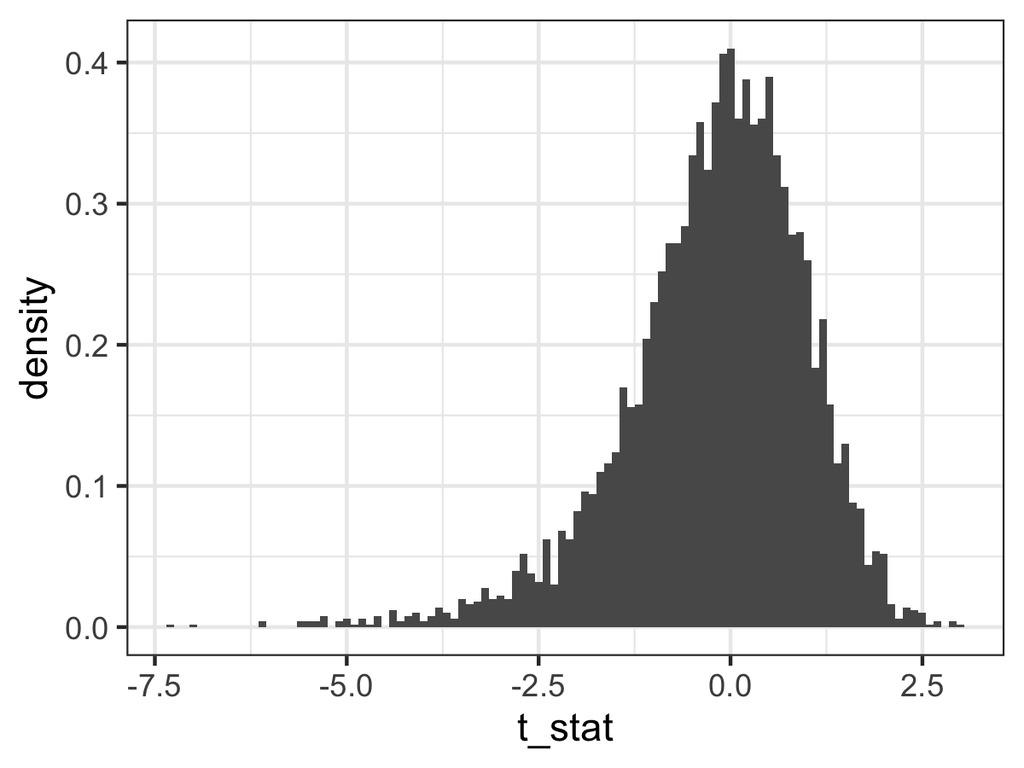

```r
ggplot(bootstrap_samples,
       aes(x = t_stat)) +
  geom_histogram(binwidth = 0.1,
                 aes(y = ..density..))
```

`\(\hat{t}_{1-\alpha/2}\)` and `\(\hat{t}_{\alpha/2}\)` are by definition the numbers that cut-off `\(1-\alpha/2\)` and `\(\alpha/2\)` of the area to the right, respectively.

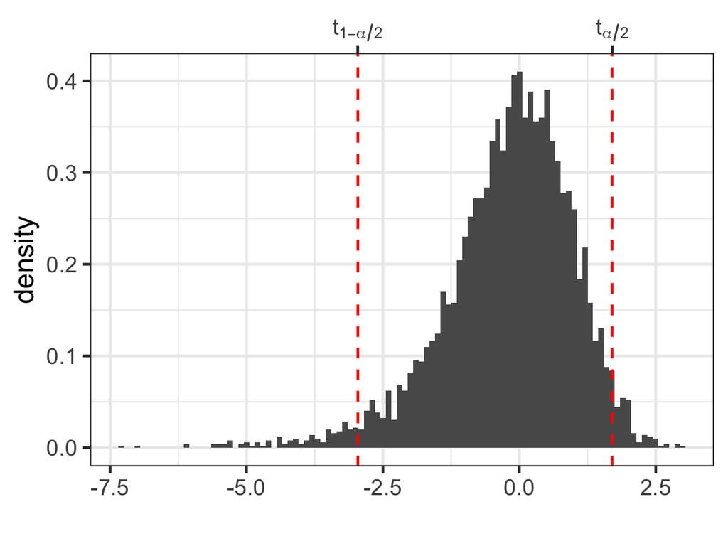

In this case, the numbers are:

```r
bootstrap_samples %>%
  summarize(t_left = quantile(t_stat, 0.025),
            t_right = quantile(t_stat, 0.975))
```

```
## # A tibble: 1 x 2
##   t_left t_right
##    <dbl>   <dbl>
## 1  -2.96    1.70
```

So,

$$
`\begin{aligned}
  1-\alpha &= P\left(\hat{t}_{1-\alpha/2} \le \frac{\bar{X} - E(\bar{X})}{\widehat{\text{SD}}(\bar{X})} \le \hat{t}_{\alpha/2}\right) \\
           &\\
           &= P\left(\hat{t}_{1-\alpha/2}\widehat{\text{SD}}(\bar{X}) \le \bar{X} - \mu \le \hat{t}_{\alpha/2}\widehat{\text{SD}}(\bar{X})\right) \\
           &\\
           &= P\left(-\bar{X}+\hat{t}_{1-\alpha/2}\widehat{\text{SD}}(\bar{X}) \le - \mu \le -\bar{X} + \hat{t}_{\alpha/2}\widehat{\text{SD}}(\bar{X})\right) \\
           &\\
           &= P\left(\bar{X}-\hat{t}_{1-\alpha/2}\widehat{\text{SD}}(\bar{X}) \ge \mu \ge \bar{X} - \hat{t}_{\alpha/2}\widehat{\text{SD}}(\bar{X})\right) \\
           &\\
           &= P\left(\bar{X}-\hat{t}_{\alpha/2}\widehat{\text{SD}}(\bar{X}) \le \mu \le \bar{X} - \hat{t}_{1-\alpha/2}\widehat{\text{SD}}(\bar{X})\right)
\end{aligned}`
$$

A `\((1-\alpha)\cdot 100\%\)` Confidence Interval for the true mean `\(\mu\)` is `\([\bar{X}-\hat{t}_{\alpha/2}\widehat{\text{SD}}(\bar{X}), \bar{X} - \hat{t}_{1-\alpha/2}\widehat{\text{SD}}(\bar{X})]\)`.

We are `\((1-\alpha)\cdot 100\%\)` confident that the true value is in this interval.

The `ChickWeight` data have data regarding the effect of diet on early growth of chicks.

```r
ChickWeight
```

```
## # A tibble: 578 x 4
##    weight  Time Chick Diet
##     <dbl> <dbl> <ord> <fct>
##  1     42     0 1     1
##  2     51     2 1     1
##  3     59     4 1     1
##  4     64     6 1     1
##  5     76     8 1     1
##  6     93    10 1     1
##  7    106    12 1     1
##  8    125    14 1     1
##  9    149    16 1     1
## 10    171    18 1     1
## # … with 568 more rows
```

We are interested in the mean birth weight of the chicks. This would not be affected by the diet, so treat as one big sample.

Want to find a confidence interval for `\(\mu\)` = true mean birth weight.

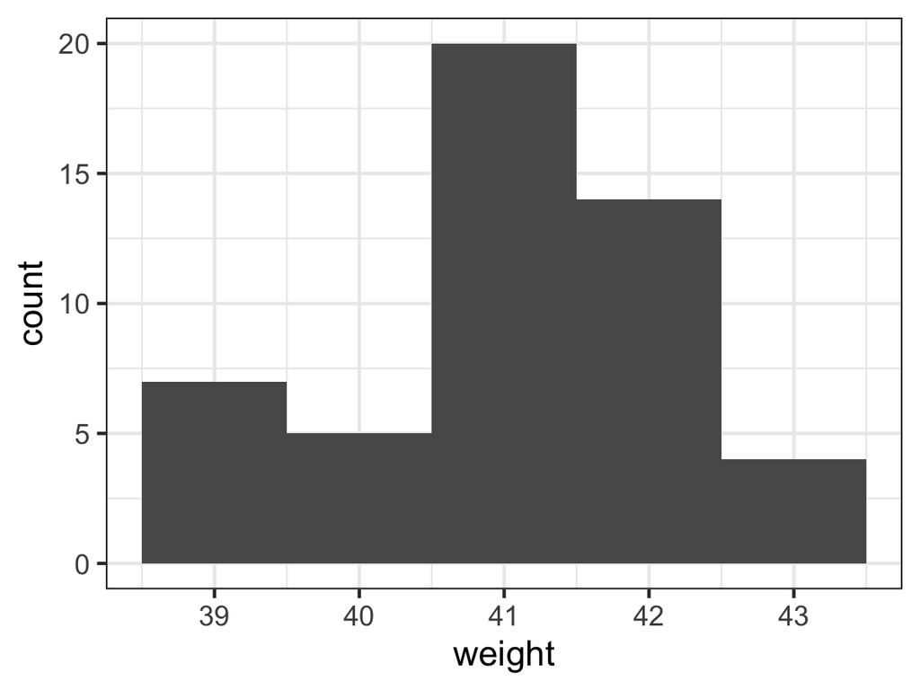

```r
birth_weights <- ChickWeight %>% filter(Time == 0)

ggplot(birth_weights,
       aes(x = weight)) +
  geom_histogram(binwidth = 1)
```

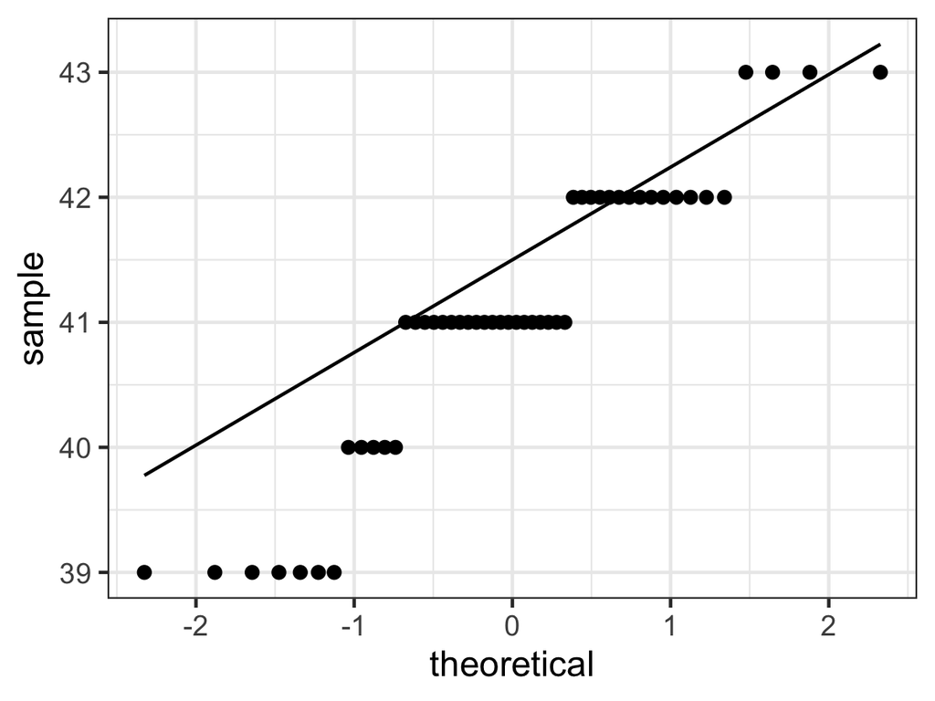

```r
ggplot(birth_weights,
       aes(sample = weight)) +
  geom_qq() +
  geom_qq_line()
```

Definitely not normal.

BUT... `\(n = 50\)`! So, by CLT `\(\bar{X} \sim N\)`. Therefore, can construct a CI. Since we do not know true `\(\sigma\)`, find a `\(90\%\)` CI as `\(\bar{x} \pm t_{n-1, 0.05} \frac{s}{\sqrt{n}}\)`.

What is `\(t_{n-1,0.05}\)`? The value on x-axis such that we cut-off `\(0.05\)` to the right.

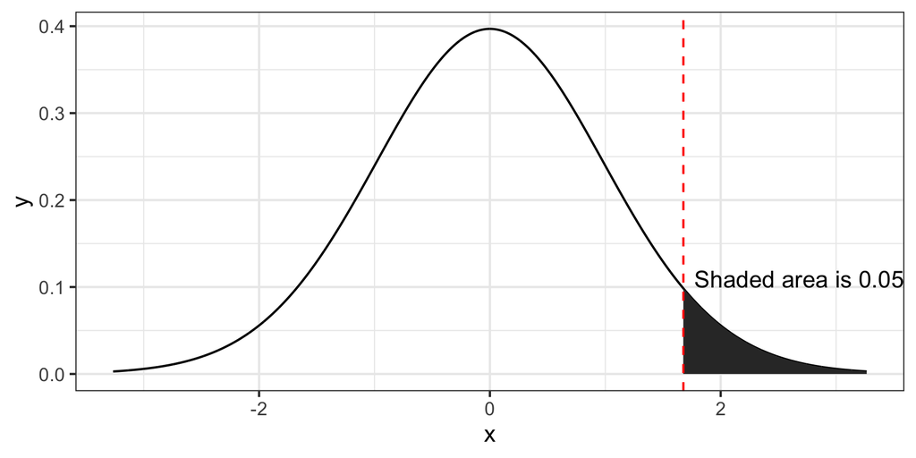

In R: remember that `quanile` finds the cut-off that cuts off to the left. To cut off 0.05 to the right, we cut off 0.95 to the left:

```r
T_49 <- StudentsT(df = 49) # n-1

(t_crit <- quantile(T_49, 0.95))
```

```
## [1] 1.676551
```

So, `\(90\%\)` CI is

```r
birth_weights %>%
  summarize(mean = mean(weight),
            sd = sd(weight),
            LL = mean - t_crit * sd/sqrt(50),
            UL = mean + t_crit * sd/sqrt(50))
```

```
## # A tibble: 1 x 4
##    mean    sd    LL    UL
##   <dbl> <dbl> <dbl> <dbl>
## 1  41.1  1.13  40.8  41.3
```

Measuring water quality over time. Done by measuring biochemical oxygen demand.

Data:

```r
BOD
```

```
##   Time demand
## 1    1    8.3
## 2    2   10.3
## 3    3   19.0
## 4    4   16.0
## 5    5   15.6
## 6    7   19.8
```

`\(n\)` small, so cannot use CLT to conclude that `\(\bar{X} \sim N\)`. However, if the data is normal, we can still get to that same conclusion!

QQ-plot:

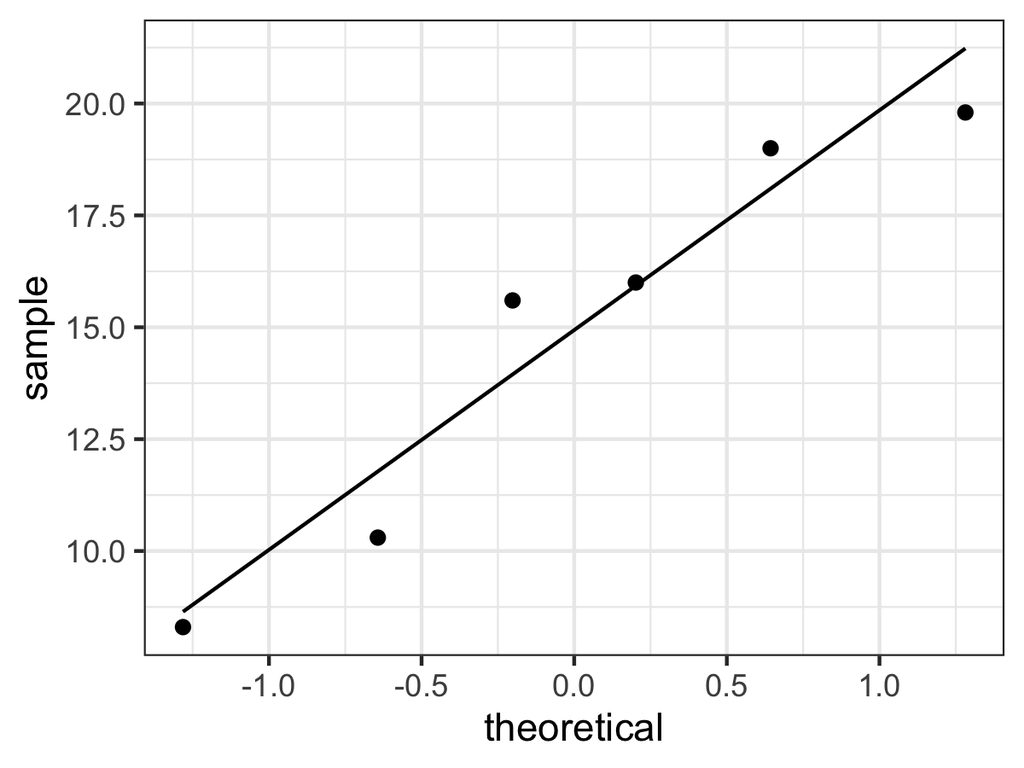

```r
ggplot(BOD, aes(sample = demand)) +
  geom_qq() +
  geom_qq_line()
```

Is it straight enough? Not sure. Compare to other samples of same size that are *actually* from a normal with same mean and SD as our sample. Then ask: does our sample seem that much different?

```r
X <- Normal(mu = mean(BOD$demand), sigma = sd(BOD$demand))

normal_samples <- tibble(i = 1:9) %>%
  mutate(data = map(i, ~random(X, n = nrow(BOD)))) %>%
  unnest_longer(data)
```

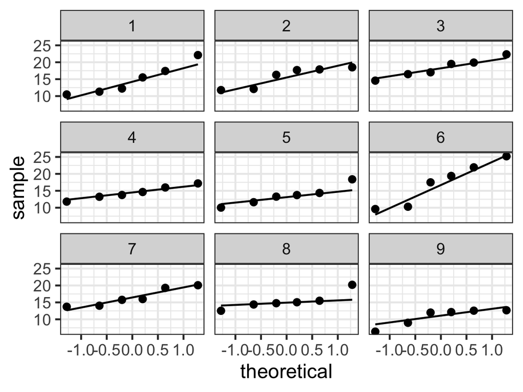

```r
ggplot(normal_samples,
       aes(sample = data)) +
  geom_qq() +
  geom_qq_line() +
  facet_wrap(~i)
```

I would probably say no.

So, we assume `\(X_1, ..., X_6 \sim N\)`. We do not know `\(\sigma\)`, so find `\(99\%\)` CI as `\(\bar{x} \pm t_{n-1,0.005} \frac{s}{\sqrt{n}}\)`.

```r
T_5 <- StudentsT(df = 5) # n-1

(t_crit <- quantile(T_5, 0.995))
```

```
## [1] 4.032143
```

```r
BOD %>%
  summarize(mean = mean(demand),
            sd = sd(demand),
            LL = mean - t_crit * sd/sqrt(50),
            UL = mean + t_crit * sd/sqrt(50))
```

```
##       mean       sd       LL       UL
## 1 14.83333 4.630623 12.19281 17.47386
```

Scientists are interested in the effect of soporific drugs on amount of sleep. Data actually has data for 10 patients in 2 groups, but we will only consider one of the groups.

```r
sleep1 <- sleep %>% filter(group == 1)
sleep1
```

```
##    extra group ID
## 1    0.7     1  1
## 2   -1.6     1  2
## 3   -0.2     1  3
## 4   -1.2     1  4
## 5   -0.1     1  5
## 6    3.4     1  6
## 7    3.7     1  7
## 8    0.8     1  8
## 9    0.0     1  9
## 10   2.0     1 10
```

Small `\(n\)`, so no CLT. Is it normal?

QQ-plot:

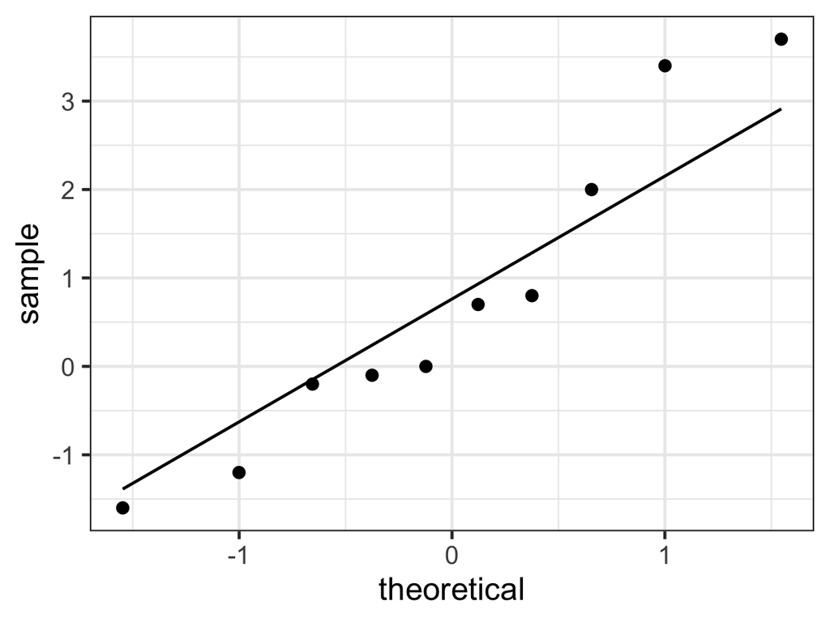

```r
ggplot(sleep1,
       aes(sample = extra)) +
  geom_qq() +
  geom_qq_line()
```

Is it straight enough? Not sure. Compare to other samples of same size that are *actually* from a normal with same mean and SD as our sample. Then ask: does our sample seem that much different?

```r
X <- Normal(mu = mean(sleep1$extra), sigma = sd(sleep1$extra))

normal_samples <- tibble(i = 1:9) %>%
  mutate(data = map(i, ~random(X, n = nrow(sleep1)))) %>%
  unnest_longer(data)
```

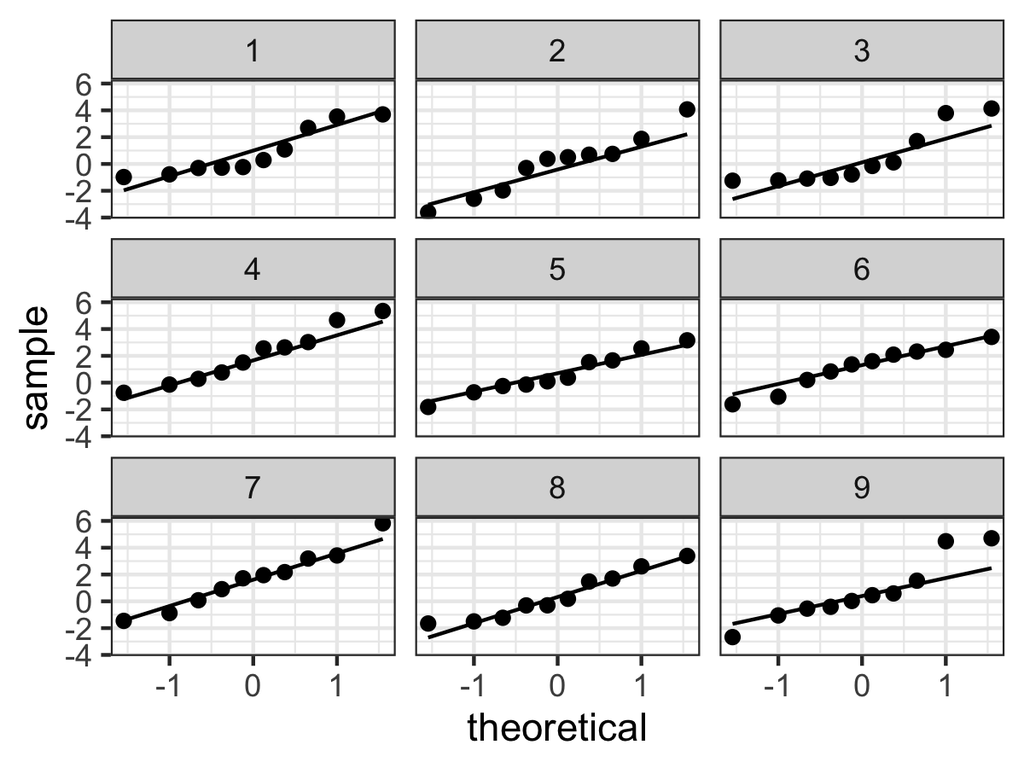

```r
ggplot(normal_samples,
       aes(sample = data)) +
  geom_qq() +
  geom_qq_line() +
  facet_wrap(~i)
```

Not sure. After consulting with the scientists in charge of the study, it is decided that we do **NOT** want to assume normality.

So, non-normal data, and `\(n\)` too small for CLT. So, we opt for a bootstrap approach:

```r
xbar <- mean(sleep1$extra)

bootstrap_samples <- tibble(i = 1:5000) %>%
  mutate(boot_samples = map(i, ~sample_n(sleep1, size = 10, replace = TRUE)$extra),
         boot_mean = map_dbl(boot_samples, mean),
         boot_sd = map_dbl(boot_samples, sd),
         t_stat = (boot_mean - xbar)/(boot_sd/sqrt(10)))
```

Distribution from bootstrap:

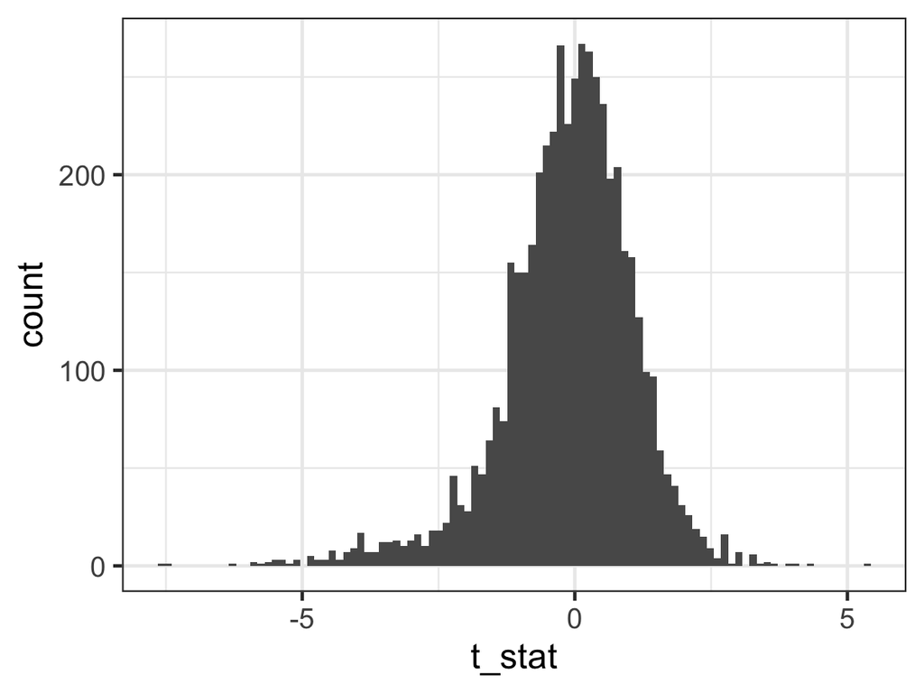

```r
ggplot(data = bootstrap_samples,
       aes(x = t_stat)) +
  geom_histogram(bins = 100)
```

Want to create a `\(95\%\)` CI for the true mean. Find `\(\hat{t}_{0.025}\)` and `\(\hat{t}_{0.975}\)`:

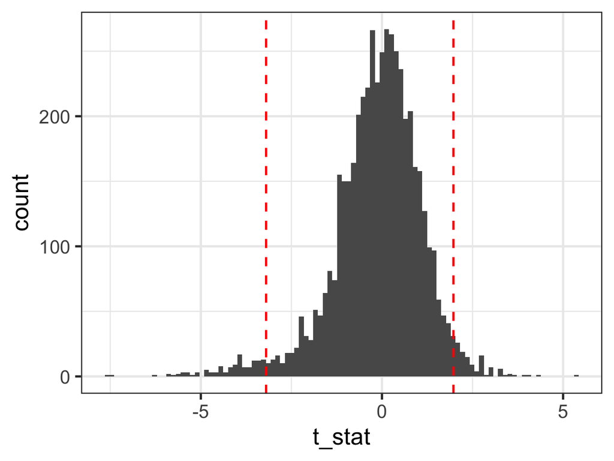

```r
ggplot(data = bootstrap_samples,
       aes(x = t_stat)) +
  geom_histogram(bins = 100) +
  geom_vline(xintercept = quantile(bootstrap_samples$t_stat,
                                   p = c(0.025, 0.975)),
             color = "red", linetype = "dashed")
```

We find these, estimated mean ( `\(\bar{x}\)` ), and standard deviation ( `\(s\)` ) in R

```r
bootstrap_samples %>%
  summarize(t_left = quantile(t_stat, 0.025),
            t_right = quantile(t_stat, 0.975))
```

```
## # A tibble: 1 x 2
##   t_left t_right
##    <dbl>   <dbl>
## 1  -3.20    1.97
```

```r
sleep1 %>%
  summarize(mean = mean(extra),
            sd = sd(extra),
            n = n())
```

```
##   mean      sd  n
## 1 0.75 1.78901 10
```

So, we find the lower limit of `\(95\%\)` CI as

$$
`\begin{aligned}
\bar{x} - \hat{t}_{0.975} \frac{s}{\sqrt{n}} &= 0.75 - 1.973\frac{1.789}{\sqrt{10}}\\
&= -0.37
\end{aligned}`
$$

and the upper limit as

$$
`\begin{aligned}
\bar{x} - \hat{t}_{0.025} \frac{s}{\sqrt{n}} &= 0.75 - (-3.198)\frac{1.789}{\sqrt{10}}\\
&= 2.56
\end{aligned}`
$$